# Projecting Carson Wentz's Trades impact on the Philadelphia Eagles 2022 Draft Picks

By Kai Canoll

### Synopsis:

```
1) 75% of offensive snaps for the Colts.
2) 70% of offensive snaps and the Colts have to make the playoffs.
```

If these conditions are not met, the Eagles will instead recieve a 2nd round pick from the Colts.

Now, as you can imagine, this leaves a huge distribution of possible draft picks the Eagles could recieve from the 1st and 2nd round.

Each final compensatory pick has it's own probability of occurence, however, and I am here to try an project it!

### Sources:

Look here for how I got my info:

Sportsipy has good stats info for free on players: https://sportsreference.readthedocs.io/en/stable/examples.html

538 has good projections on the season: https://data.fivethirtyeight.com/#nfl-elo

Fantasy Pros has info on Carsons Rolling Offensive Snap % Count by Week https://www.fantasypros.com/nfl/reports/snap-counts/qb.php?year=2021&show=perc&print=true

## Change Variables of Interest Here

## Get Game Win Probs from FiveThirtyEight

## Find Postseason Projection for each team

## All Teams Playoff Postseason Odds Dataframe

## Specifically Colts Chances at Each Round of Playoffs

## Find Current Carson Wentz Snap Percentage

## List of Team Abbreviations

### Playoff adjusted for picks 19-32

Adjusting for playoff odds is a little hard with what 538 gave me. Instead, I'm using "http://www.playoffstatus.com/nfl/nflpostseasonprob.html" which has the chances of Colts winning each theoretical playoff game

## Actual Simulation Loop (Takes up to 15 minutes, sorry)

## Compile DataFrame of Simulations

## Take a look at Simulation Dataframe, each row is an outcome

## Average Snap Percentage by Carson

```
Carson's Average Final Expected Overall Snap Percentage is 86.572%
```

# Average Draft Pick Colts

```
The Average Compensation Pick From Colts to the Eagles is Pick #20.1011
```

## Highest Occuring Draft Pick

```
The Most Likely Compensation Pick From Colts to the Eagles is Pick #14
```

## Histogram of All Draft Picks

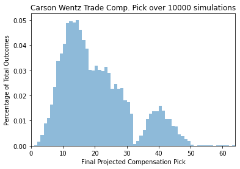

## CDF of Draft Picks

[interactive chart not shown]

## Chance of Draft Pick in the First Round

```
The Eagles received a 1st Round Pick in 85.52% of all simulations.
```

## Chance of Top 20 Pick

```
The Eagles received a pick in the top 20 in 59.33% of all simulations.
```

## Chance of Top 10 Pick

```
The Eagles received a pick in the top 10 in 17.7% of all simulations.
```

## Chance of Top 5 Pick

```
The Eagles received a pick in the top 5 in 2.62% of all simulations.
```

## Lowest Probable Pick

```
63
```

## Highest Probable Pick

```
1
```

## Average Pick By First Quarter Result

```
First Quarter Wins
1    20.1011
Name: Final Pick, dtype: float64
```

## Average Pick by Halfway Point Result

```
Second Quarter Wins
1    26.928977
2    21.494695
3    18.619735
4    19.859253
5    22.145455
Name: Final Pick, dtype: float64
```

## Average Pick by Third Quarter Result

```
Third Quarter Wins
1    35.500000
2    31.348148
3    25.324832
4    20.501453
5    17.477126
6    19.593512
7    21.892641
8    23.457565
9    24.652174
Name: Final Pick, dtype: float64
```

## Desired Wins By Third Quarter for Eagles

### This number of wins by week 13 would represent the lowest average comp. pick

```
5
```

## Draft Pick by Time Out of Playoff Picture

[interactive chart not shown]

## Total Wins For Indy and Average Draft Pick

[interactive chart not shown]

## Making Playoffs vs. NOT

[interactive chart not shown]

## Probability Distribution of Final Pick based off of each Quarter (every 4 games) Result

### First Quarter of Season Done

[interactive chart not shown]

### Season Halfway Done

[interactive chart not shown]

### Third Quarter Done

[interactive chart not shown]

## Analysis

There is no guarantee that the rules of this simulation accurately map out the thought process of the Colts front office. The organization is famously incompetent and prone to misusing their players. Through the first few weeks of this 2021 season, Carson has played admirably under intense pressure from both the media and opposing defensive lines. As long as he is availible and healthy, he will be fighting for his starting job in the league, and the Colts may not be able to bench him so easily even in a losing season if his performance is this good.

Regardless, even after an 1-3 start, this distribution should show Eagles fans that a pick in the top 5 is essentially a pipe dream.